# Washington ZEV Demand After Two Market Shocks

Monthly title transactions, fuel pressure, and stated preferences

MSBA 580 Project Group

July 2026

# Executive report

## Decision question

Washington vehicle manufacturers, dealers, and policy analysts need to know whether the early-2026 gasoline-price shock produced a meaningful ZEV-demand rebound after Washington and federal incentives rolled off in 2025. We ask: **Did Washington’s share of new light-duty ZEV title transactions rise after the war, and was that movement distinguishable from the post-incentive-rolloff market?**

The answer is cautious. Washington’s pooled ZEV-title share increased from 13.9% in November 2025–February 2026 to 14.5% in March–June 2026, a 0.56-point increase, while average regular gasoline prices rose 33.8%. An interrupted time-series model estimates an additional post-war change of 1.15 percentage points, but it is not statistically distinct from zero (Newey–West p = 0.285). The evidence does not yet show that fuel pressure restored the demand lost after incentives rolled off. Lagged gasoline prices add modest predictive information, but the result is sensitive to the electricity-price control.

## Data and definitions

The primary source is the Washington Department of Licensing’s public [Vehicle Title Transactions](https://data.wa.gov/Transportation/Vehicle-Title-Transactions-by-Department-of-Licens/cdk6-5kdf) API. The pipeline uses 114 consecutive months from January 2017 through June 2026. It requires original titles, the DOL new-vehicle flag, Washington owner state, passenger cars/multipurpose vehicles/light trucks, and light-duty weight classes. ZEVs include BEVs, PHEVs, and hydrogen fuel-cell vehicles.

This measure is a registration transaction, not a dealer sale date. Title processing can lag purchase timing, so October 2025 remains in the incentive-transition/processing period and the modeled post-rolloff period begins in November. Washington’s clean-vehicle sales-tax exemption ended July 31, 2025, shortly before the federal credit ended September 30, so their effects cannot be separated reliably. Washington gasoline prices come from the [U.S. Energy Information Administration](https://www.eia.gov/dnav/pet/hist/LeafHandler.ashx?f=W&n=PET&s=EMM_EPMR_PTE_SWA_DPG). California Energy Commission quarterly sales are retained only as a neighboring comparison because their timing and construction differ.

## Analytical methods

The first technique is a pre-event regression benchmark trained through June 2025. We compare seasonal-only, linear-time, and quadratic-time models, each including calendar-month effects and a COVID disruption indicator. Rolling one-month-ahead validation covers 42 months. The quadratic specification has the lowest RMSE, 3.66 percentage points, narrowly outperforming the linear model’s 3.78 points.

The second specification is an interrupted time series using all 114 months. It adds combined post-incentive-rolloff and post-war level indicators to the quadratic trend, seasonality, and COVID control. Newey–West standard errors address residual autocorrelation. Event coefficients describe deviations associated with each period; they do not identify causal effects.

The third specification tests gasoline-price association. Current and lagged gasoline measures are compared using the same rolling window. The prior-three-month average performs best and is then fit with trend, seasonality, COVID, Washington incentive timing, and the combined rolloff period. Washington unemployment, electricity prices, and a post-war indicator are added separately as sensitivity checks.

Monthly Washington titles materially improve the study design over the earlier California-only quarterly approach. They provide enough pre-event history to estimate recurring seasonal patterns, reserve 42 months for rolling forecast validation, and distinguish the credit transition from the later war period. The county panel then tests whether the statewide change was geographically broad or driven by one large market. California is not pooled into the regression: it serves only as a directional comparison because California reports inferred sales while Washington reports title transactions.

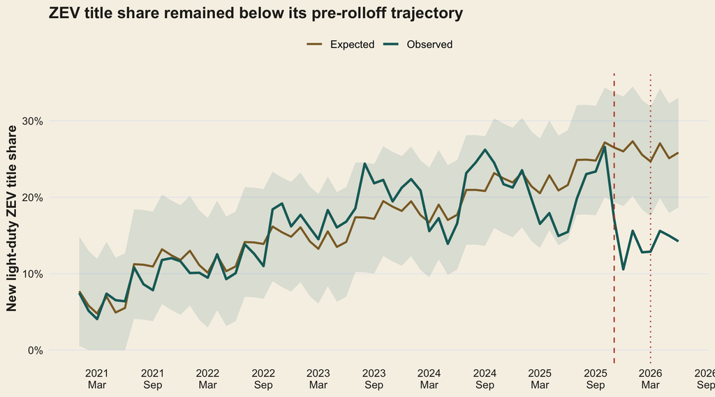

Observed Washington ZEV-title share and the pre-rolloff benchmark.

## Findings

The benchmark expected a pooled 25.7% ZEV-title share during March–June 2026, 11.2 points above the observed 14.5%. The interrupted model estimates a combined post-incentive-rolloff level shift of −11.59 points (p < 0.001). Its additional post-war coefficient is positive but uncertain: +1.15 points with a 95% interval from −0.97 to +3.28 points.

Gasoline prices averaged $3.90 per gallon in the four post-rolloff/pre-war months and $5.22 during the four post-war months. Thus, higher fuel costs coincided with only a small title-share increase. This is inconsistent with a large immediate fuel-price-driven recovery, although purchasing and title processing may respond with longer lags.

The prior-three-month gas measure reduces rolling RMSE from 3.66 to 3.37 percentage points, a 7.9% improvement. The policy-adjusted estimate is +2.77 ZEV-share percentage points per $1/gallon (95% CI +0.27 to +5.27; p = 0.031). After adding Washington electricity prices, the estimate is +2.00 points and its interval includes zero (p = 0.118). The result is therefore a modest, specification-sensitive predictive association, not a causal effect.

FHWA VMT was 1.0% below the same month one year earlier in preliminary May 2026 data. VMT is treated as a separate behavioral outcome rather than a ZEV-share control because driving can itself respond to gasoline prices.

County patterns were more favorable but heterogeneous. Thirty-two of 39 counties increased ZEV-title share, and the median change was +3.34 points. Among large markets, Pierce gained 4.70 points, Snohomish 4.51, and Clark 6.90, while King declined 3.18. County results exclude the DOL’s “Unknown or Out of State” category and should not be treated as independent statewide experiments.

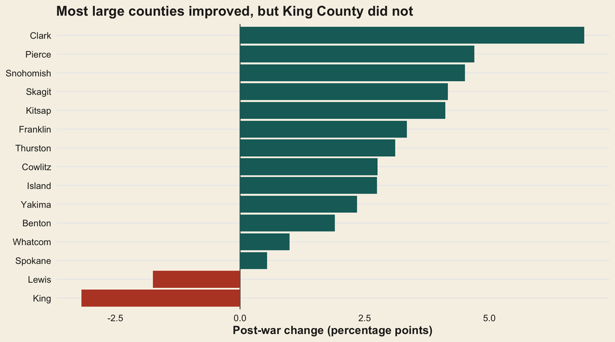

Change in ZEV-title share for the 15 largest county markets.

The rating-based conjoint survey adds stated-preference evidence from 123 ratings supplied by 18 respondents. Price is the clearest attribute (cluster-robust p = 0.013): a $30,000 profile scores 1.30 preference points above a $120,000 profile (p = 0.005). Brand and fuel economy cannot be cleanly separated because Tesla was consistently paired with 110 MPGe.

## Recommendations and limitations

Managers should avoid a broad Washington inventory expansion based on four post-war months. Prioritize affordability and total-cost messaging, then monitor whether title share continues improving as gasoline prices remain elevated. County-level campaigns are more defensible in markets showing both scale and positive movement, such as Pierce, Snohomish, and Clark.

The study is observational. Washington and federal policy, manufacturer incentives, interest rates, vehicle prices, model availability, title-processing delays, and the war overlap. The state and federal incentive expirations are especially difficult to separate. The post-war period is short, the gas-association estimate weakens with electricity prices, rolling forecast error is material, and the conjoint sample is small and partially confounded. Later DOL releases are needed before claiming a durable rebound.

## Sources

- [Washington Department of Licensing title transactions](https://data.wa.gov/Transportation/Vehicle-Title-Transactions-by-Department-of-Licens/cdk6-5kdf)
- [EIA Washington regular gasoline prices](https://www.eia.gov/dnav/pet/hist/LeafHandler.ashx?f=W&n=PET&s=EMM_EPMR_PTE_SWA_DPG)
- [BLS Washington unemployment](https://data.bls.gov/timeseries/LAUST530000000000003)
- [FHWA Traffic Volume Trends](https://www.fhwa.dot.gov/policyinformation/travel_monitoring/tvt.cfm)
- [Washington clean-vehicle sales-tax exemption](https://dor.wa.gov/forms-publications/publications-subject/special-notices/new-clean-alternative-fuel-and-plug-hybrid-vehicle-sales-and-use-tax-exemption)
- [Washington EV Instant Rebate](https://www.commerce.wa.gov/clean-transportation/ev-instant-rebate/)
- [California Energy Commission ZEV sales](https://www.energy.ca.gov/data-reports/energy-almanac/zero-emission-vehicle-and-infrastructure-statistics-collection/new-zev)